# Part 3

Daniel Herrera

11/23/2021

```r
library(tidyverse)
library(caret)
```

```r
library(rpart)
library(rpart.plot)
library(e1071)
library(randomForest)
library(mice)
library(survival)
library(survminer)
bone <- read.csv("data.csv")

# remove HLA_match_raw (was already converted into a different column)
bone <- select(bone, -HLA_match_raw)


# convert numeric columns to numeric
bone_num <- c("donor_age", "recipient_age", "recipient_body_mass", "CD34_x1e6_per_kg...CD34kgx10d6",
           "CD3_x1e8_per_kg", "CD3_to_CD34_ratio", "ANC_recovery", "PLT_recovery",
           "time_to_acute_GvHD_III_IV", "survival_time", "survival_status")

bone[,bone_num] <- lapply(bone_num, function(x) as.numeric(bone[[x]]))
```

We will begin by exploring our missing data for CMV status. This variable is deemed important by our domain experts so we need to explore why there appears to be missingness to decide on the most reasonable steps to handle this missingness.

```r
bone %>%
  group_by(CMV_status) %>%
  tally()
```

```
## # A tibble: 5 x 2
##   CMV_status     n
##   <chr>      <int>
## 1 ?             16
## 2 0             48
## 3 1             27
## 4 2             57
## 5 3             39
```

There are 16 individuals which have missing values for cmv_status.

We will first explore the outcomes of the individuals with missing values.

```r
bone %>%
  group_by(CMV_status) %>%
  summarize( n = n(), survivers = sum(survival_status), deceased = n - survivers, percent_surv = survivers/n)
```

```
## # A tibble: 5 x 5
##   CMV_status     n survivers deceased percent_surv
##   <chr>      <int>     <dbl>    <dbl>        <dbl>
## 1 ?             16        10        6        0.625
## 2 0             48        22       26        0.458
## 3 1             27         9       18        0.333
## 4 2             57        26       31        0.456
## 5 3             39        18       21        0.462
```

We can try to explore other variables that may be useful when trying to understand if this difference is meaningful.

It appears, roughly, that there is some overlap in the percentage of the total that are receive bone marrow as the stem cell source among the missing compared to other groups. Additionally, there appears to be overlap in the missing values compared to other cmv_status levels with respect to recipient body mass. Lastly, there also appears to roughly be a similar proportion of males/females in the missing cmv status group compared to other levels.

```r
# cmv_satus and stem cell source
bone %>%
  group_by(CMV_status) %>%
  summarize( n = n(), `peripheral blood` = sum(stem_cell_source == "peripheral_blood"), `bone marrow` = sum(stem_cell_source == "bone_marrow"), bm_proportion = `bone marrow`/n)
```

```
## # A tibble: 5 x 5
##   CMV_status     n `peripheral blood` `bone marrow` bm_proportion
##   <chr>      <int>              <int>         <int>         <dbl>
## 1 ?             16                 12             4         0.25
## 2 0             48                 35            13         0.271
## 3 1             27                 22             5         0.185
## 4 2             57                 43            14         0.246
## 5 3             39                 33             6         0.154
```

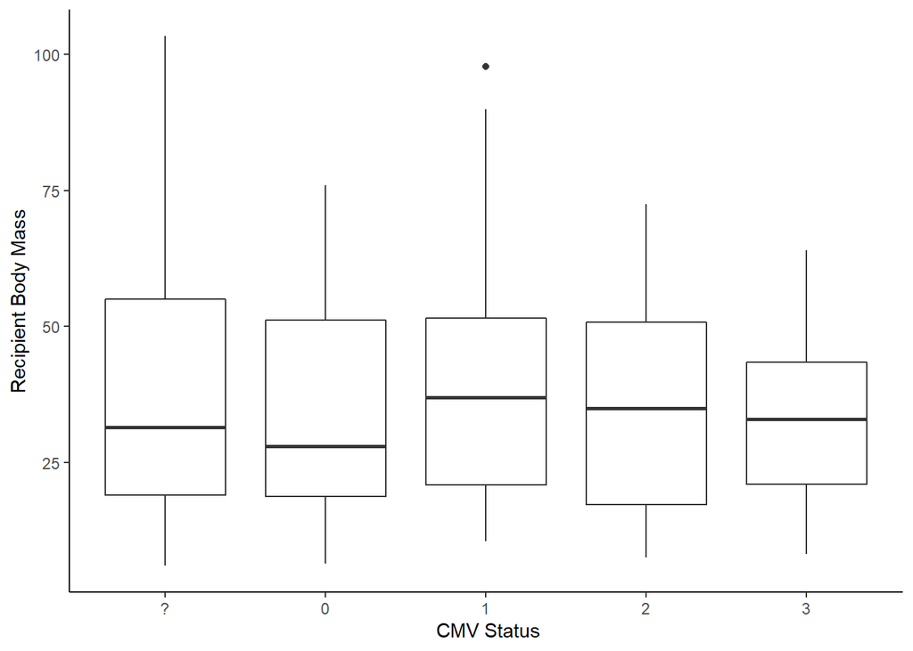

```r
# cmv_status and recipient body mass

ggplot(data = bone, aes(x = as.factor(CMV_status), y = recipient_body_mass)) +
  geom_boxplot() +
  xlab(" CMV Status") +
  ylab("Recipient Body Mass") +
  theme_classic()
```

```r
# cmv and gender
bone %>%
  group_by(CMV_status) %>%
  summarize( n = n(), `male recipient` = sum(recipient_gender == "male"), `female recipient` = sum(recipient_gender == "female"), `male proportion` = `male recipient` / n)
```

```
## # A tibble: 5 x 5
##   CMV_status     n `male recipient` `female recipient` `male proportion`
##   <chr>      <int>            <int>              <int>             <dbl>
## 1 ?             16                8                  8             0.5
## 2 0             48               32                 16             0.667
## 3 1             27               16                 11             0.593
## 4 2             57               35                 22             0.614
## 5 3             39               21                 18             0.538
```

#### Naive approach

We will perform several supervised learning techniques using a training and testing split of the complete cases to try to predict survival status effectively.

Note: There are 5 missing cd3 values. This is an important variable so we may have to address this further. For now we will drop these 5 values as well; however, we will try to impute them later using the MICE package.

```r
# attempt at a similar "full model"

predictors <- bone[,c(1:27,37)] # selects only predictors and survival (the outcome)

# make NA the ones with missing CMV status
predictors_CMV <- predictors %>%
  mutate(CMV_status = na_if(CMV_status, "?"))


#find complete cases only
comp_cases_CMV <- predictors_CMV %>%
  drop_na()

# use only variables which are not redundant and avoid possibility of multicolinearity
comp_cases_CMV <- comp_cases_CMV %>%
  select(c(survival_status, recipient_age, recipient_gender, recipient_body_mass,
           recipient_ABO, recipient_rh, recipient_CMV, donor_age, stem_cell_source, disease, gender_match, ABO_match, CMV_status,stem_cell_source, CD34_x1e6_per_kg...CD34kgx10d6, CD3_x1e8_per_kg))


# Create test/train data
set.seed(1)
# split test and training data into 50/50
trainIndex <- createDataPartition(comp_cases_CMV$survival_status, p = .7,
                                  list = FALSE,
                                  times = 1)
train_set <- comp_cases_CMV[ trainIndex,]
test_set <- comp_cases_CMV[-trainIndex,]
```

We have parsed out some variables due to concerns of collinearity due to variables measuring the same or similar metrics. We remove variables included in recipient and donor that can be summarized by ’…_match" variables to remove this redundancy.

Our model here has an accuracy of 61.22%.

```r
# attempt at a similar "full model"

logistic_full <- glm(survival_status ~ .,
    family = binomial(), data = train_set)

summary(logistic_full)
```

```
##
## Call:
## glm(formula = survival_status ~ ., family = binomial(), data = train_set)
##
## Deviance Residuals:
##     Min       1Q   Median       3Q      Max
## -1.8588  -0.8994  -0.5649   1.1065   2.1770
##
## Coefficients: (1 not defined because of singularities)
##                                    Estimate Std. Error z value Pr(>|z|)
## (Intercept)                       1.559e+01  2.400e+03   0.006    0.995
## recipient_age                    -7.935e-02  1.017e-01  -0.780    0.435
## recipient_gendermale              4.353e-01  5.065e-01   0.860    0.390
## recipient_body_mass               3.447e-02  2.849e-02   1.210    0.226
## recipient_ABOA                    2.271e-01  5.926e-01   0.383    0.702
## recipient_ABOAB                   1.628e+00  9.906e-01   1.643    0.100
## recipient_ABOB                   -2.234e-02  6.094e-01  -0.037    0.971
## recipient_rhminus                -1.858e+01  2.400e+03  -0.008    0.994
## recipient_rhplus                 -1.677e+01  2.400e+03  -0.007    0.994
## recipient_CMVpresent             -1.007e-02  6.480e-01  -0.016    0.988
## donor_age                         9.127e-03  2.741e-02   0.333    0.739
## stem_cell_sourceperipheral_blood  2.454e-02  7.131e-01   0.034    0.973
## diseaseAML                       -8.147e-02  7.155e-01  -0.114    0.909
## diseasechronic                    3.535e-01  6.106e-01   0.579    0.563
## diseaselymphoma                   1.721e+01  1.128e+03   0.015    0.988
## diseasenonmalignant              -3.987e-01  7.106e-01  -0.561    0.575
## gender_matchother                 2.275e-01  6.869e-01   0.331    0.740
## ABO_matchmismatched               1.109e-01  5.341e-01   0.208    0.836
## CMV_status1                      -1.032e+00  7.488e-01  -1.379    0.168
## CMV_status2                      -2.132e-01  5.883e-01  -0.362    0.717
## CMV_status3                              NA         NA      NA       NA
## CD34_x1e6_per_kg...CD34kgx10d6   -1.052e-02  3.333e-02  -0.316    0.752
## CD3_x1e8_per_kg                  -6.824e-02  1.012e-01  -0.674    0.500
##
## (Dispersion parameter for binomial family taken to be 1)
##
##     Null deviance: 156.81  on 116  degrees of freedom
## Residual deviance: 129.57  on  95  degrees of freedom
## AIC: 173.57
##
## Number of Fisher Scoring iterations: 15
```

```r
# create predictions and calc accuracy


glm_probs <- predict(logistic_full, newdata = test_set, type = "response")
glm_preds <- ifelse(glm_probs > 0.5, 1, 0)

confusionMatrix(data = as.factor(glm_preds),
                reference = as.factor(test_set$survival_status),
                positive = "1")
```

```
## Confusion Matrix and Statistics
##
##           Reference
## Prediction  0  1
##          0 17 12
##          1  7 13
##
##                Accuracy : 0.6122
##                  95% CI : (0.4624, 0.748)
##     No Information Rate : 0.5102
##     P-Value [Acc > NIR] : 0.09887
##
##                   Kappa : 0.2274
##
##  Mcnemar's Test P-Value : 0.35880
##
##             Sensitivity : 0.5200
##             Specificity : 0.7083
##          Pos Pred Value : 0.6500
##          Neg Pred Value : 0.5862
##              Prevalence : 0.5102
##          Detection Rate : 0.2653
##    Detection Prevalence : 0.4082
##       Balanced Accuracy : 0.6142
##
##        'Positive' Class : 1
##
```

Let’s try using step selection to see which variables may be more important to include in our supervised learning models.

Forward step and backwards step selection determine that CD3 dosage, recipient RH status, disease type and recipient body mass are most important. We will keep cmv_status as important due to our domain knowledge experts.

```r
library(broom)
mod_basic <- glm(survival_status ~ 1, data=comp_cases_CMV, family = "binomial")
stepModel <- step(mod_basic, direction="forward",
                  scope=(~recipient_age+ recipient_gender+ recipient_body_mass+
           recipient_ABO+ recipient_rh+ recipient_CMV+ donor_age+ stem_cell_source+ disease+ gender_match+ ABO_match+ CMV_status+stem_cell_source+ CD34_x1e6_per_kg...CD34kgx10d6+ CD3_x1e8_per_kg),
                  data=comp_cases_CMV)
```

```
## Start:  AIC=228.64
## survival_status ~ 1
##
##                                  Df Deviance    AIC
## + CD3_x1e8_per_kg                 1   218.12 222.12
## + CD34_x1e6_per_kg...CD34kgx10d6  1   218.58 222.58
## + recipient_body_mass             1   218.99 222.99
## + disease                         4   214.61 224.61
## + recipient_rh                    2   219.17 225.17
## + recipient_age                   1   222.00 226.00
## + stem_cell_source                1   223.60 227.60
## <none>                                226.64 228.64
## + ABO_match                       1   224.72 228.72
## + donor_age                       1   225.95 229.95
## + recipient_CMV                   1   226.26 230.26
## + recipient_gender                1   226.64 230.64
## + gender_match                    1   226.64 230.64
## + CMV_status                      3   224.71 232.71
## + recipient_ABO                   3   225.49 233.49
##
## Step:  AIC=222.12
## survival_status ~ CD3_x1e8_per_kg
##
##                                  Df Deviance    AIC
## + recipient_rh                    2   211.24 219.24
## + disease                         4   208.17 220.17
## + recipient_body_mass             1   215.08 221.08
## + ABO_match                       1   216.11 222.11
## <none>                                218.12 222.12
## + CD34_x1e6_per_kg...CD34kgx10d6  1   216.27 222.27
## + recipient_age                   1   216.75 222.75
## + donor_age                       1   217.33 223.33
## + recipient_CMV                   1   217.64 223.64
## + gender_match                    1   218.07 224.07
## + recipient_gender                1   218.09 224.09
## + stem_cell_source                1   218.11 224.11
## + recipient_ABO                   3   216.50 226.50
## + CMV_status                      3   216.63 226.63
##
## Step:  AIC=219.24
```

[output cut: 35 more lines]

```
## survival_status ~ CD3_x1e8_per_kg + recipient_rh + disease +
##     recipient_body_mass
##
##                                  Df Deviance    AIC
## <none>                                197.88 215.88
## + recipient_age                   1   196.73 216.73
## + ABO_match                       1   197.20 217.20
## + CD34_x1e6_per_kg...CD34kgx10d6  1   197.57 217.57
## + recipient_CMV                   1   197.59 217.59
## + donor_age                       1   197.59 217.59
## + stem_cell_source                1   197.61 217.61
## + gender_match                    1   197.67 217.67
## + recipient_gender                1   197.85 217.85
## + CMV_status                      3   196.33 220.33
## + recipient_ABO                   3   196.45 220.45
```

```r
tidy(stepModel)
```

```
## # A tibble: 9 x 5
##   term                estimate  std.error statistic p.value
##   <chr>                  <dbl>      <dbl>     <dbl>   <dbl>
## 1 (Intercept)          16.6    2400.        0.00694  0.994
## 2 CD3_x1e8_per_kg      -0.0914    0.0544   -1.68     0.0931
## 3 recipient_rhminus   -18.3    2400.       -0.00764  0.994
## 4 recipient_rhplus    -17.1    2400.       -0.00711  0.994
## 5 diseaseAML            0.216     0.483     0.447    0.655
## 6 diseasechronic        0.279     0.433     0.645    0.519
## 7 diseaselymphoma      17.0     932.        0.0183   0.985
## 8 diseasenonmalignant  -0.107     0.511    -0.209    0.835
## 9 recipient_body_mass   0.0136    0.00956   1.42     0.156
```

```r
mod_back <- glm(survival_status ~ recipient_age + recipient_gender+ recipient_body_mass+
           recipient_ABO+ recipient_rh+ recipient_CMV+ donor_age+ stem_cell_source+ disease+ gender_match+ ABO_match+ CMV_status+stem_cell_source+ CD34_x1e6_per_kg...CD34kgx10d6+ CD3_x1e8_per_kg,
                data = comp_cases_CMV,
                family = "binomial")

backStepModel <- step(mod_back,
                      direction = "backward",
                      data = comp_cases_CMV)
```

```
## Start:  AIC=236.41
## survival_status ~ recipient_age + recipient_gender + recipient_body_mass +
##     recipient_ABO + recipient_rh + recipient_CMV + donor_age +
##     stem_cell_source + disease + gender_match + ABO_match + CMV_status +
##     stem_cell_source + CD34_x1e6_per_kg...CD34kgx10d6 + CD3_x1e8_per_kg
##
##                                  Df Deviance    AIC
## - CMV_status                      3   192.38 232.38
## - recipient_ABO                   3   193.03 233.03
## - recipient_gender                1   190.41 234.41
## - stem_cell_source                1   190.53 234.53
## - donor_age                       1   190.54 234.54
## - gender_match                    1   190.56 234.56
## - CD34_x1e6_per_kg...CD34kgx10d6  1   190.60 234.60
## - recipient_CMV                   1   190.75 234.75
## - CD3_x1e8_per_kg                 1   191.19 235.19
## - ABO_match                       1   191.19 235.19
## <none>                                190.41 236.41
## - recipient_age                   1   192.61 236.61
## - recipient_body_mass             1   194.02 238.02
## - disease                         4   201.12 239.12
## - recipient_rh                    2   197.78 239.78
##
## Step:  AIC=232.38
## survival_status ~ recipient_age + recipient_gender + recipient_body_mass +
##     recipient_ABO + recipient_rh + recipient_CMV + donor_age +
##     stem_cell_source + disease + gender_match + ABO_match + CD34_x1e6_per_kg...CD34kgx10d6 +
##     CD3_x1e8_per_kg
##
##                                  Df Deviance    AIC
## - recipient_ABO                   3   194.46 228.46
## - recipient_gender                1   192.39 230.39
## - donor_age                       1   192.45 230.45
## - stem_cell_source                1   192.52 230.52
## - CD34_x1e6_per_kg...CD34kgx10d6  1   192.55 230.55
## - gender_match                    1   192.68 230.68
## - recipient_CMV                   1   193.12 231.12
## - ABO_match                       1   193.49 231.49
## - CD3_x1e8_per_kg                 1   193.49 231.49
## - recipient_age                   1   194.21 232.21
```

[output cut: 130 more lines]

```
## - recipient_body_mass  1   199.33 217.33
## - CD3_x1e8_per_kg      1   199.77 217.77
## - disease              4   208.15 220.15
## - recipient_rh         2   204.35 220.35
##
## Step:  AIC=215.88
## survival_status ~ recipient_body_mass + recipient_rh + disease +
##     CD3_x1e8_per_kg
##
##                       Df Deviance    AIC
## <none>                     197.88 215.88
## - recipient_body_mass  1   199.93 215.93
## - CD3_x1e8_per_kg      1   200.84 216.84
## - disease              4   208.62 218.62
## - recipient_rh         2   205.56 219.56
```

```r
tidy(backStepModel)
```

```
## # A tibble: 9 x 5
##   term                estimate  std.error statistic p.value
##   <chr>                  <dbl>      <dbl>     <dbl>   <dbl>
## 1 (Intercept)          16.6    2400.        0.00694  0.994
## 2 recipient_body_mass   0.0136    0.00956   1.42     0.156
## 3 recipient_rhminus   -18.3    2400.       -0.00764  0.994
## 4 recipient_rhplus    -17.1    2400.       -0.00711  0.994
## 5 diseaseAML            0.216     0.483     0.447    0.655
## 6 diseasechronic        0.279     0.433     0.645    0.519
## 7 diseaselymphoma      17.0     932.        0.0183   0.985
## 8 diseasenonmalignant  -0.107     0.511    -0.209    0.835
## 9 CD3_x1e8_per_kg      -0.0914    0.0544   -1.68     0.0931
```

We can now try this approach using only the model variables determined as important by forward and backwards step selection. We get an accuracy of 63.27% using this approach, which is slightly higher than our initial full model.

```r
mod_log <- glm(survival_status ~ stem_cell_source + recipient_body_mass + as.factor(recipient_rh) + disease + CD3_x1e8_per_kg,
               data = train_set,
               family = binomial())
summary(mod_log)
```

```
##
## Call:
## glm(formula = survival_status ~ stem_cell_source + recipient_body_mass +
##     as.factor(recipient_rh) + disease + CD3_x1e8_per_kg, family = binomial(),
##     data = train_set)
##
## Deviance Residuals:
##     Min       1Q   Median       3Q      Max
## -1.4708  -0.9473  -0.6195   1.1501   2.0641
##
## Coefficients:
##                                    Estimate Std. Error z value Pr(>|z|)
## (Intercept)                        16.50767 2399.54484   0.007    0.995
## stem_cell_sourceperipheral_blood    0.11147    0.65507   0.170    0.865
## recipient_body_mass                 0.01550    0.01277   1.213    0.225
## as.factor(recipient_rh)minus      -18.50027 2399.54484  -0.008    0.994
## as.factor(recipient_rh)plus       -17.18348 2399.54475  -0.007    0.994
## diseaseAML                         -0.03578    0.63087  -0.057    0.955
## diseasechronic                      0.45367    0.52643   0.862    0.389
## diseaselymphoma                    17.37785 1142.89260   0.015    0.988
## diseasenonmalignant                -0.17815    0.60772  -0.293    0.769
## CD3_x1e8_per_kg                    -0.09734    0.09429  -1.032    0.302
##
## (Dispersion parameter for binomial family taken to be 1)
##
##     Null deviance: 156.81  on 116  degrees of freedom
## Residual deviance: 136.02  on 107  degrees of freedom
## AIC: 156.02
##
## Number of Fisher Scoring iterations: 15
```

```r
glm_probs <- predict(mod_log, newdata = test_set, type = "response")
glm_preds <- ifelse(glm_probs > 0.5, 1, 0)

confusionMatrix(data = as.factor(glm_preds),
                reference = as.factor(test_set$survival_status),
                positive = "1")
```

```
## Confusion Matrix and Statistics
##
##           Reference
## Prediction  0  1
##          0 21 15
##          1  3 10
##
##                Accuracy : 0.6327
##                  95% CI : (0.4829, 0.7658)
##     No Information Rate : 0.5102
##     P-Value [Acc > NIR] : 0.057378
##
##                   Kappa : 0.2723
##
##  Mcnemar's Test P-Value : 0.009522
##
##             Sensitivity : 0.4000
##             Specificity : 0.8750
##          Pos Pred Value : 0.7692
##          Neg Pred Value : 0.5833
##              Prevalence : 0.5102
##          Detection Rate : 0.2041
##    Detection Prevalence : 0.2653
##       Balanced Accuracy : 0.6375
##
##        'Positive' Class : 1
##
```

###### KNN

Now we can try this approach of full and reduced models using k-nearest neighbors, bayes, decision trees and random forests. We will have to drop one value which is missing, denoted as ‘?’ from the recipient RH variable.

With the full model we have an accuracy of 55.1%, meanwhile with the reduced model we have an accuracy of 65.31%

```r
# full model

train_knn <- train_set[-which(train_set$recipient_rh == "?"),]

knn_full <- knn3(survival_status ~., data = train_knn)

knn_probs <- predict(knn_full, newdata = test_set)[,2]
knn_preds <- ifelse(knn_probs > 0.5, 1, 0)

confusionMatrix(data = as.factor(knn_preds),
                reference = as.factor(test_set$survival_status),
                positive = "1")
```

```
## Confusion Matrix and Statistics
##
##           Reference
## Prediction  0  1
##          0 18 16
##          1  6  9
##
##                Accuracy : 0.551
##                  95% CI : (0.4023, 0.6933)
##     No Information Rate : 0.5102
##     P-Value [Acc > NIR] : 0.33460
##
##                   Kappa : 0.1091
##
##  Mcnemar's Test P-Value : 0.05501
##
##             Sensitivity : 0.3600
##             Specificity : 0.7500
##          Pos Pred Value : 0.6000
##          Neg Pred Value : 0.5294
##              Prevalence : 0.5102
##          Detection Rate : 0.1837
##    Detection Prevalence : 0.3061
##       Balanced Accuracy : 0.5550
##
##        'Positive' Class : 1
##
```

```r
#reduced model
# remove one ? value row for rh
train_knn <- train_set[-which(train_set$recipient_rh == "?"),]


knn_red <- knn3(survival_status ~ stem_cell_source + recipient_body_mass + as.factor(recipient_rh) + disease + CD3_x1e8_per_kg, data = train_knn)

knn_probs_red <- predict(knn_red, newdata = test_set)[,2]
knn_preds_red <- ifelse(knn_probs_red > 0.5, 1, 0)

confusionMatrix(data = as.factor(knn_preds_red),
                reference = as.factor(test_set$survival_status),
                positive = "1")
```

```
## Confusion Matrix and Statistics
##
##           Reference
## Prediction  0  1
##          0 21 14
##          1  3 11
##
##                Accuracy : 0.6531
##                  95% CI : (0.5036, 0.7833)
##     No Information Rate : 0.5102
##     P-Value [Acc > NIR] : 0.03089
##
##                   Kappa : 0.3121
##
##  Mcnemar's Test P-Value : 0.01529
##
##             Sensitivity : 0.4400
##             Specificity : 0.8750
##          Pos Pred Value : 0.7857
##          Neg Pred Value : 0.6000
##              Prevalence : 0.5102
##          Detection Rate : 0.2245
##    Detection Prevalence : 0.2857
##       Balanced Accuracy : 0.6575
##
##        'Positive' Class : 1
##
```

###### Naive Bayes

With the reduced model, we obtain an accuracy of 61.22% using the Naive Bayes approach compared to 57.14% with the full model.

```r
# full model
nb_full <- naiveBayes(survival_status ~ ., data = train_set)
nb_preds <- predict(nb_full, newdata = test_set)


confusionMatrix(data = as.factor(nb_preds),
                reference = as.factor(test_set$survival_status),
                positive = "1")
```

```
## Confusion Matrix and Statistics
##
##           Reference
## Prediction  0  1
##          0 15 12
##          1  9 13
##
##                Accuracy : 0.5714
##                  95% CI : (0.4221, 0.7118)
##     No Information Rate : 0.5102
##     P-Value [Acc > NIR] : 0.2378
##
##                   Kappa : 0.1446
##
##  Mcnemar's Test P-Value : 0.6625
##
##             Sensitivity : 0.5200
##             Specificity : 0.6250
##          Pos Pred Value : 0.5909
##          Neg Pred Value : 0.5556
##              Prevalence : 0.5102
##          Detection Rate : 0.2653
##    Detection Prevalence : 0.4490
##       Balanced Accuracy : 0.5725
##
##        'Positive' Class : 1
##
```

```r
# reduced model
nb_red <- naiveBayes(survival_status ~ stem_cell_source + recipient_body_mass + as.factor(recipient_rh) + disease + CD3_x1e8_per_kg, data = train_set)
nb_preds <- predict(nb_red, newdata = test_set)


confusionMatrix(data = as.factor(nb_preds),
                reference = as.factor(test_set$survival_status),
                positive = "1")
```

```
## Confusion Matrix and Statistics
##
##           Reference
## Prediction  0  1
##          0 19 14
##          1  5 11
##
##                Accuracy : 0.6122
##                  95% CI : (0.4624, 0.748)
##     No Information Rate : 0.5102
##     P-Value [Acc > NIR] : 0.09887
##
##                   Kappa : 0.2299
##
##  Mcnemar's Test P-Value : 0.06646
##
##             Sensitivity : 0.4400
##             Specificity : 0.7917
##          Pos Pred Value : 0.6875
##          Neg Pred Value : 0.5758
##              Prevalence : 0.5102
##          Detection Rate : 0.2245
##    Detection Prevalence : 0.3265
##       Balanced Accuracy : 0.6158
##
##        'Positive' Class : 1
##
```

###### Decision Tree

We will now use decision trees to make predictions of survival status.

With our full model, the accuracy of the decision trees is 61.22%, meanwhile our reduced model has an accuracy of 59.18%.

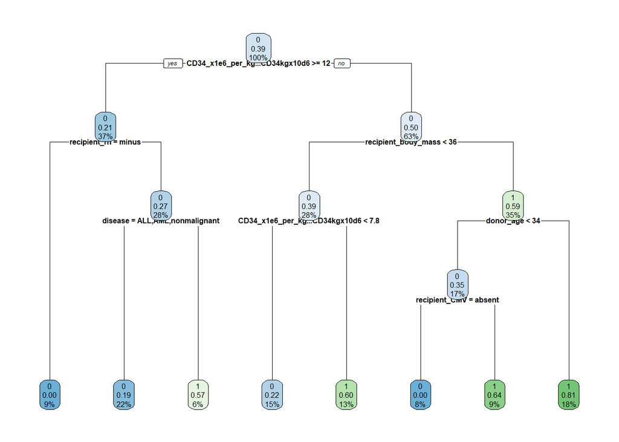

```r
# full
fit <- rpart(as.factor(survival_status) ~ ., data = train_set)

# will plot the tree
rpart.plot(fit, cex = 0.5)
```

```r
# create new dataframe without survival outcomes
# df <- subset(cases_comp2, select = -c(survival_status))

#make predicitons and cutoffs
mypreds <- predict(fit, test_set)
tree_preds <- ifelse(mypreds[,2] > 0.5, 1, 0)


confusionMatrix(data = as.factor(tree_preds),
                reference = as.factor(test_set$survival_status),
                positive = "1")
```

```
## Confusion Matrix and Statistics
##
##           Reference
## Prediction  0  1
##          0 14  9
##          1 10 16
##
##                Accuracy : 0.6122
##                  95% CI : (0.4624, 0.748)
##     No Information Rate : 0.5102
##     P-Value [Acc > NIR] : 0.09887
##
##                   Kappa : 0.2235
##
##  Mcnemar's Test P-Value : 1.00000
##
##             Sensitivity : 0.6400
##             Specificity : 0.5833
##          Pos Pred Value : 0.6154
##          Neg Pred Value : 0.6087
##              Prevalence : 0.5102
##          Detection Rate : 0.3265
##    Detection Prevalence : 0.5306
##       Balanced Accuracy : 0.6117
##
##        'Positive' Class : 1
##
```

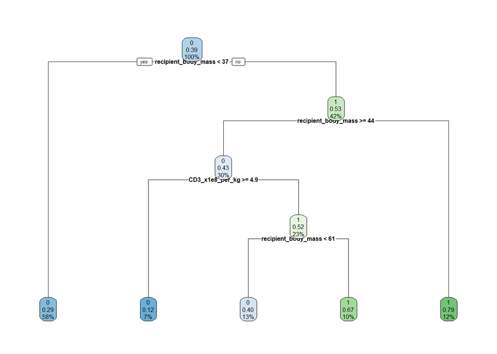

```r
fit <- rpart(as.factor(survival_status) ~ stem_cell_source + recipient_body_mass + as.factor(recipient_rh) + disease + CD3_x1e8_per_kg, data = train_set)

# will plot the tree
rpart.plot(fit, cex = 0.5)
```

```r
# create new dataframe without survival outcomes
# df <- subset(cases_comp2, select = -c(survival_status))

#make predicitons and cutoffs
mypreds <- predict(fit, test_set)
tree_preds <- ifelse(mypreds[,2] > 0.5, 1, 0)


confusionMatrix(data = as.factor(tree_preds),
                reference = as.factor(test_set$survival_status),
                positive = "1")
```

```
## Confusion Matrix and Statistics
##
##           Reference
## Prediction  0  1
##          0 21 17
##          1  3  8
##
##                Accuracy : 0.5918
##                  95% CI : (0.4421, 0.73)
##     No Information Rate : 0.5102
##     P-Value [Acc > NIR] : 0.15862
##
##                   Kappa : 0.1928
##
##  Mcnemar's Test P-Value : 0.00365
##
##             Sensitivity : 0.3200
##             Specificity : 0.8750
##          Pos Pred Value : 0.7273
##          Neg Pred Value : 0.5526
##              Prevalence : 0.5102
##          Detection Rate : 0.1633
##    Detection Prevalence : 0.2245
##       Balanced Accuracy : 0.5975
##
##        'Positive' Class : 1
##
```

###### Random Forests

We will use the same training data as the knn which removes the one rh = “?” value.

```r
#full model
set.seed(1)
fit_bag <- randomForest(as.factor(survival_status) ~ ., ntree = 100, data = train_knn)

forest_pred <- predict(fit, newdata = test_set, type = "class")
confusionMatrix(table(pred = forest_pred, true = test_set$survival_status), positive = "1")
```

```
## Confusion Matrix and Statistics
##
##     true
## pred  0  1
##    0 21 17
##    1  3  8
##
##                Accuracy : 0.5918
##                  95% CI : (0.4421, 0.73)
##     No Information Rate : 0.5102
##     P-Value [Acc > NIR] : 0.15862
##
##                   Kappa : 0.1928
##
##  Mcnemar's Test P-Value : 0.00365
##
##             Sensitivity : 0.3200
##             Specificity : 0.8750
##          Pos Pred Value : 0.7273
##          Neg Pred Value : 0.5526
##              Prevalence : 0.5102
##          Detection Rate : 0.1633
##    Detection Prevalence : 0.2245
##       Balanced Accuracy : 0.5975
##
##        'Positive' Class : 1
##
```

```r
# reduced model
set.seed(1)
red_bag <- randomForest(as.factor(survival_status) ~ stem_cell_source + recipient_body_mass + recipient_rh +  disease + CD3_x1e8_per_kg, ntree = 100, data = train_knn)

forest_pred_red <- predict(red_bag, newdata = test_set, type = "class")
confusionMatrix(table(pred = forest_pred_red, true = test_set$survival_status), positive = "1")
```

```
## Confusion Matrix and Statistics
##
##     true
## pred  0  1
##    0 20 13
##    1  4 12
##
##                Accuracy : 0.6531
##                  95% CI : (0.5036, 0.7833)
##     No Information Rate : 0.5102
##     P-Value [Acc > NIR] : 0.03089
##
##                   Kappa : 0.311
##
##  Mcnemar's Test P-Value : 0.05235
##
##             Sensitivity : 0.4800
##             Specificity : 0.8333
##          Pos Pred Value : 0.7500
##          Neg Pred Value : 0.6061
##              Prevalence : 0.5102
##          Detection Rate : 0.2449
##    Detection Prevalence : 0.3265
##       Balanced Accuracy : 0.6567
##
##        'Positive' Class : 1
##
```

**In summary, the highest accuracy was attained using the reduced models for K-Nearest Neighbors and for Random Forests at 65.31%.**

###### ROC Curves

We create ROC Curves using our Naive approach where imputation for missing CMV status is not conducted.

```r
library(pROC)
# knn reduced model
roc_knn <- roc(test_set$survival_status, knn_preds_red)
# random forest model
roc_rf <- roc(test_set$survival_status, as.numeric(levels(forest_pred_red))[forest_pred_red])
```

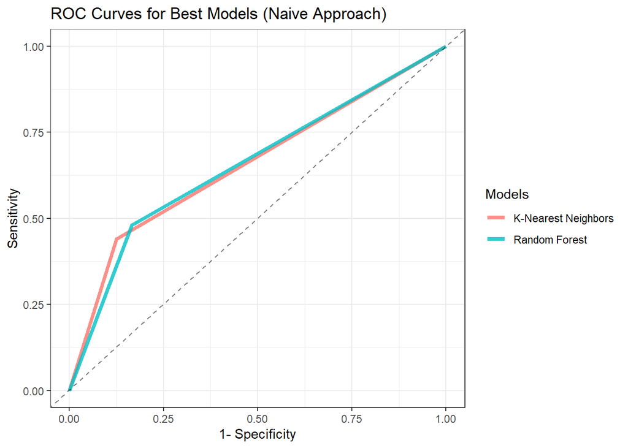

```r
ggroc(list("K-Nearest Neighbors" = roc_knn, "Random Forest" = roc_rf), legacy.axes = T, size = 1.5, alpha = 0.8) +
  geom_abline(color = "black", linetype = "dashed", alpha = 0.5) +
  xlab("1- Specificity") +
  ylab("Sensitivity") +
  ggtitle("ROC Curves for Best Models (Naive Approach)") +
  labs(color = "Models")  +
  theme_bw()
```

```r
auc(roc_knn)
```

```
## Area under the curve: 0.6575
```

```r
auc(roc_rf)
```

```
## Area under the curve: 0.6567
```

# Redo using reduced and with Imputation

We will use the predictors data set, before we removed missing values, and recode “?” to be NA. Then we can use use imputation to get values for CMV_status.

```r
predictors_CMV <- predictors %>%
  mutate(CMV_status = na_if(CMV_status, "?")) %>%
  mutate(CMV_status = as.factor(CMV_status))


imp <- mice(predictors_CMV, method = "rf", m = 1)
data_imp <- complete(imp)
```

We can recreate our dataset using inputed values for CMV_status

```r
#find complete cases only
comp_cases2 <- data_imp %>%
  drop_na()

# use only variables which are not redundant and avoid possibility of multicolinearity
comp_cases2 <- comp_cases2 %>%
  select(c(survival_status, recipient_age, recipient_gender, recipient_body_mass,
           recipient_ABO, recipient_rh, recipient_CMV, donor_age, stem_cell_source, disease, gender_match, ABO_match, CMV_status,stem_cell_source, CD34_x1e6_per_kg...CD34kgx10d6, CD3_x1e8_per_kg))


# Create test/train data
set.seed(1)
# split test and training data into 50/50
trainIndex <- createDataPartition(comp_cases2$survival_status, p = .7,
                                  list = FALSE,
                                  times = 1)
train_set2 <- comp_cases2[ trainIndex,]
test_set2 <- comp_cases2[-trainIndex,]
```

Now, we can retry our two best models from previously (KNN and randomForests) to see what occurs for our accuracy. We will again have to remove the one case where RH status is “?”

```r
#KNN
# full
train_knn2 <- train_set2[-which(train_set2$recipient_rh == "?"),]

knn_full2 <- knn3(survival_status ~., data = train_knn2)

knn_probs2 <- predict(knn_full2, newdata = test_set2)[,2]
knn_preds2 <- ifelse(knn_probs2 > 0.5, 1, 0)


confusionMatrix(data = as.factor(knn_preds2),
                reference = as.factor(test_set2$survival_status),
                positive = "1")
```

```
## Confusion Matrix and Statistics
##
##           Reference
## Prediction  0  1
##          0 20 17
##          1  9 10
##
##                Accuracy : 0.5357
##                  95% CI : (0.3974, 0.6701)
##     No Information Rate : 0.5179
##     P-Value [Acc > NIR] : 0.4475
##
##                   Kappa : 0.0606
##
##  Mcnemar's Test P-Value : 0.1698
##
##             Sensitivity : 0.3704
##             Specificity : 0.6897
##          Pos Pred Value : 0.5263
##          Neg Pred Value : 0.5405
##              Prevalence : 0.4821
##          Detection Rate : 0.1786
##    Detection Prevalence : 0.3393
##       Balanced Accuracy : 0.5300
##
##        'Positive' Class : 1
##
```

```r
# reduced

knn_red2 <- knn3(survival_status ~ stem_cell_source + recipient_body_mass + as.factor(recipient_rh) + disease + CD3_x1e8_per_kg, data = train_knn2)

knn_probs_red2 <- predict(knn_red2, newdata = test_set2)[,2]
knn_preds_red2 <- ifelse(knn_probs_red2 > 0.5, 1, 0)

confusionMatrix(data = as.factor(knn_preds_red2),
                reference = as.factor(test_set2$survival_status),
                positive = "1")
```

```
## Confusion Matrix and Statistics
##
##           Reference
## Prediction  0  1
##          0 21 16
##          1  8 11
##
##                Accuracy : 0.5714
##                  95% CI : (0.4322, 0.7029)
##     No Information Rate : 0.5179
##     P-Value [Acc > NIR] : 0.2524
##
##                   Kappa : 0.1329
##
##  Mcnemar's Test P-Value : 0.1530
##
##             Sensitivity : 0.4074
##             Specificity : 0.7241
##          Pos Pred Value : 0.5789
##          Neg Pred Value : 0.5676
##              Prevalence : 0.4821
##          Detection Rate : 0.1964
##    Detection Prevalence : 0.3393
##       Balanced Accuracy : 0.5658
##
##        'Positive' Class : 1
##
```

```r
#full model
set.seed(1)

fit_bag <- randomForest(as.factor(survival_status) ~ ., ntree = 100, data = train_knn2)

forest_pred2 <- predict(fit, newdata = test_set2, type = "class")
confusionMatrix(table(pred = forest_pred2, true = test_set2$survival_status))
```

```
## Confusion Matrix and Statistics
##
##     true
## pred  0  1
##    0 26 20
##    1  3  7
##
##                Accuracy : 0.5893
##                  95% CI : (0.4498, 0.719)
##     No Information Rate : 0.5179
##     P-Value [Acc > NIR] : 0.1747391
##
##                   Kappa : 0.1593
##
##  Mcnemar's Test P-Value : 0.0008492
##
##             Sensitivity : 0.8966
##             Specificity : 0.2593
##          Pos Pred Value : 0.5652
##          Neg Pred Value : 0.7000
##              Prevalence : 0.5179
##          Detection Rate : 0.4643
##    Detection Prevalence : 0.8214
##       Balanced Accuracy : 0.5779
##
##        'Positive' Class : 0
##
```

```r
#reduced model
set.seed(1)
fit_bag2 <- randomForest(as.factor(survival_status) ~ stem_cell_source + recipient_body_mass + recipient_rh + disease + CD3_x1e8_per_kg, ntree = 100, data = train_knn2)

forest_pred_red <- predict(fit_bag2, newdata = test_set2, type = "class")
confusionMatrix(table(pred = forest_pred_red, true = test_set2$survival_status))
```

```
## Confusion Matrix and Statistics
##
##     true
## pred  0  1
##    0 22 16
##    1  7 11
##
##                Accuracy : 0.5893
##                  95% CI : (0.4498, 0.719)
##     No Information Rate : 0.5179
##     P-Value [Acc > NIR] : 0.17474
##
##                   Kappa : 0.168
##
##  Mcnemar's Test P-Value : 0.09529
##
##             Sensitivity : 0.7586
##             Specificity : 0.4074
##          Pos Pred Value : 0.5789
##          Neg Pred Value : 0.6111
##              Prevalence : 0.5179
##          Detection Rate : 0.3929
##    Detection Prevalence : 0.6786
##       Balanced Accuracy : 0.5830
##
##        'Positive' Class : 0
##
```

```r
#reduced model
# random forests
set.seed(1)
fit_bag_red2 <- randomForest(as.factor(survival_status) ~ stem_cell_source + recipient_body_mass + recipient_rh + disease + CD3_x1e8_per_kg +CMV_status, ntree = 100, data = train_knn2)

forest_pred_red2 <- predict(fit_bag_red2, newdata = test_set2, type = "class")
confusionMatrix(table(pred = forest_pred_red2, true = test_set2$survival_status))
```

```
## Confusion Matrix and Statistics
##
##     true
## pred  0  1
##    0 19 17
##    1 10 10
##
##                Accuracy : 0.5179
##                  95% CI : (0.3803, 0.6534)
##     No Information Rate : 0.5179
##     P-Value [Acc > NIR] : 0.5537
##
##                   Kappa : 0.0258
##
##  Mcnemar's Test P-Value : 0.2482
##
##             Sensitivity : 0.6552
##             Specificity : 0.3704
##          Pos Pred Value : 0.5278
##          Neg Pred Value : 0.5000
##              Prevalence : 0.5179
##          Detection Rate : 0.3393
##    Detection Prevalence : 0.6429
##       Balanced Accuracy : 0.5128
##
##        'Positive' Class : 0
##
```

```r
#knn reduced with cmvstatus added

knn_red3 <- knn3(survival_status ~ stem_cell_source + recipient_body_mass + as.factor(recipient_rh) + disease + CD3_x1e8_per_kg + CMV_status, data = train_knn2)

knn_probs_red3 <- predict(knn_red3, newdata = test_set2)[,2]
knn_preds_red3 <- ifelse(knn_probs_red3 > 0.5, 1, 0)

confusionMatrix(data = as.factor(knn_preds_red3),
                reference = as.factor(test_set2$survival_status),
                positive = "1")
```

```
## Confusion Matrix and Statistics
##
##           Reference
## Prediction  0  1
##          0 22 17
##          1  7 10
##
##                Accuracy : 0.5714
##                  95% CI : (0.4322, 0.7029)
##     No Information Rate : 0.5179
##     P-Value [Acc > NIR] : 0.25235
##
##                   Kappa : 0.1307
##
##  Mcnemar's Test P-Value : 0.06619
##
##             Sensitivity : 0.3704
##             Specificity : 0.7586
##          Pos Pred Value : 0.5882
##          Neg Pred Value : 0.5641
##              Prevalence : 0.4821
##          Detection Rate : 0.1786
##    Detection Prevalence : 0.3036
##       Balanced Accuracy : 0.5645
##
##        'Positive' Class : 1
##
```

In summary, after imputation, the accuracy of our KNN reduced model and our Random Forest reduced model are lower than when using the naive approach.

##### Roc Curves after Imputation

```r
# knn reduced model
roc_knn_imp <- roc(test_set2$survival_status, knn_preds_red3)
# random forest model
roc_rf_imp <- roc(test_set2$survival_status, as.numeric(levels(forest_pred_red2))[forest_pred_red2])
```

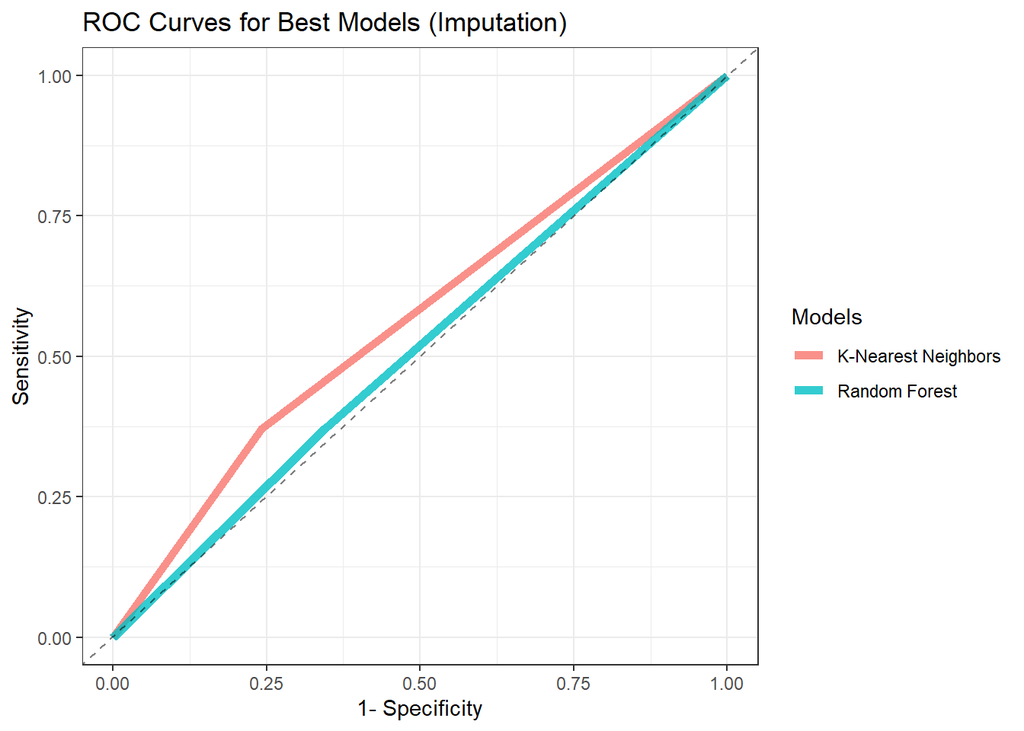

```r
ggroc(list("K-Nearest Neighbors" = roc_knn_imp, "Random Forest" = roc_rf_imp), legacy.axes = T, size = 2, alpha = 0.8) +
  geom_abline(color = "black", linetype = "dashed", alpha = 0.5) +
  xlab("1- Specificity") +
  ylab("Sensitivity") +
  ggtitle("ROC Curves for Best Models (Imputation)") +
  labs(color = "Models")  +
  theme_bw()
```

```r
auc(roc_knn_imp)
```

```
## Area under the curve: 0.5645
```

```r
auc(roc_rf_imp)
```

```
## Area under the curve: 0.5128
```

#### Survival Analysis

Firstly we know that we have a categorical value survival_status (dead = 1, alive = 0), which tracks the status of survival for our patients. We also have a variable survival_time which tracks survival time, including time to death. We do not see any indication of censorship information being tracked, so we will make the assumption that no cases were censored.

#### 1) Survival Analysis with CD3 and CD34 doses as predictors based on previous research.

We can fit the model and see the summary below. We see that the predictor CD3 dosage is significant, when both predictor variables are included. CD34 dosage is significant when only CD34 dosage is included. These finding align with the research findings previously mentioned.

The estimated hazard ratio for mortality associated with a one unit higher CD3 dose compared to those with on unit lower is 0.91621 (95% CI: 0.845, 0.9934), holding all other covariates constant, which indicates on average a 8.4% decrease in mortality. When we explore only the model with CD34 as a predictor, the estimated hazard ratio for mortality associated with a one unit higher CD34 dose compared to those with one unit lower is 0.97131 (95% CI: 0.9454, 0.9979), which indicates on average a 2.9% decrease in mortality. Both of these findings indicate a protective effect against mortality when increasing the dosage of CD3 and CD34.

```r
# compare cd34 and cd3 in survival model

cox_obj <- Surv(bone$survival_time, bone$survival_status)
cox_mod <- coxph(cox_obj ~ CD34_x1e6_per_kg...CD34kgx10d6 + CD3_x1e8_per_kg, data = bone, ties = "exact")

# provide score and LR test statistic
summary(cox_mod)
```

```
## Call:
## coxph(formula = cox_obj ~ CD34_x1e6_per_kg...CD34kgx10d6 + CD3_x1e8_per_kg,
##     data = bone, ties = "exact")
##
##   n= 182, number of events= 81
##    (5 observations deleted due to missingness)
##
##                                    coef exp(coef) se(coef)      z Pr(>|z|)
## CD34_x1e6_per_kg...CD34kgx10d6 -0.01140   0.98867  0.01661 -0.686    0.493
## CD3_x1e8_per_kg                -0.08751   0.91621  0.04127 -2.121    0.034 *
## ---
## Signif. codes:  0 '***' 0.001 '**' 0.01 '*' 0.05 '.' 0.1 ' ' 1
##
##                                exp(coef) exp(-coef) lower .95 upper .95
## CD34_x1e6_per_kg...CD34kgx10d6    0.9887      1.011     0.957    1.0214
## CD3_x1e8_per_kg                   0.9162      1.091     0.845    0.9934
##
## Concordance= 0.612  (se = 0.033 )
## Likelihood ratio test= 11.03  on 2 df,   p=0.004
## Wald test            = 9.67  on 2 df,   p=0.008
## Score (logrank) test = 9.74  on 2 df,   p=0.008
```

```r
# reduced with only cd34
cox_red <- coxph(cox_obj ~ CD34_x1e6_per_kg...CD34kgx10d6, data = bone, ties = "exact")

# provide score and LR test statistic
summary(cox_red)
```

```
## Call:
## coxph(formula = cox_obj ~ CD34_x1e6_per_kg...CD34kgx10d6, data = bone,
##     ties = "exact")
##
##   n= 187, number of events= 85
##
##                                    coef exp(coef) se(coef)      z Pr(>|z|)
## CD34_x1e6_per_kg...CD34kgx10d6 -0.02911   0.97131  0.01378 -2.112   0.0347 *
## ---
## Signif. codes:  0 '***' 0.001 '**' 0.01 '*' 0.05 '.' 0.1 ' ' 1
##
##                                exp(coef) exp(-coef) lower .95 upper .95
## CD34_x1e6_per_kg...CD34kgx10d6    0.9713       1.03    0.9454    0.9979
##
## Concordance= 0.596  (se = 0.032 )
## Likelihood ratio test= 5.26  on 1 df,   p=0.02
## Wald test            = 4.46  on 1 df,   p=0.03
## Score (logrank) test = 4.48  on 1 df,   p=0.03
```

We can now assess if this model is appropriate for the data by analyzing the weighted Schoenfeld residuals. We do not utilize log-log plots here since these predictors are continuous variables, and thus not binary. The weighted Schoenfeld residuals do not show any indication that the proportional hazards assumption does not hold in this case.

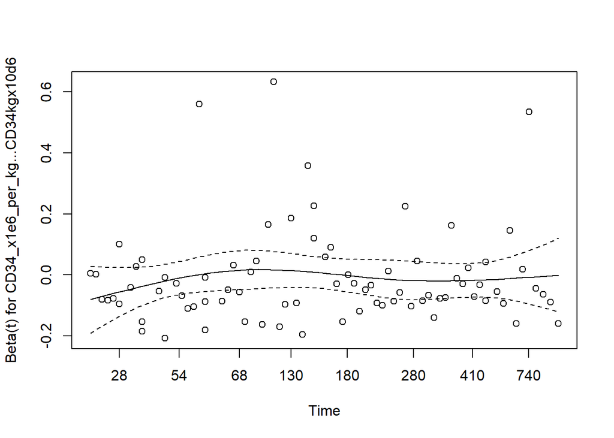

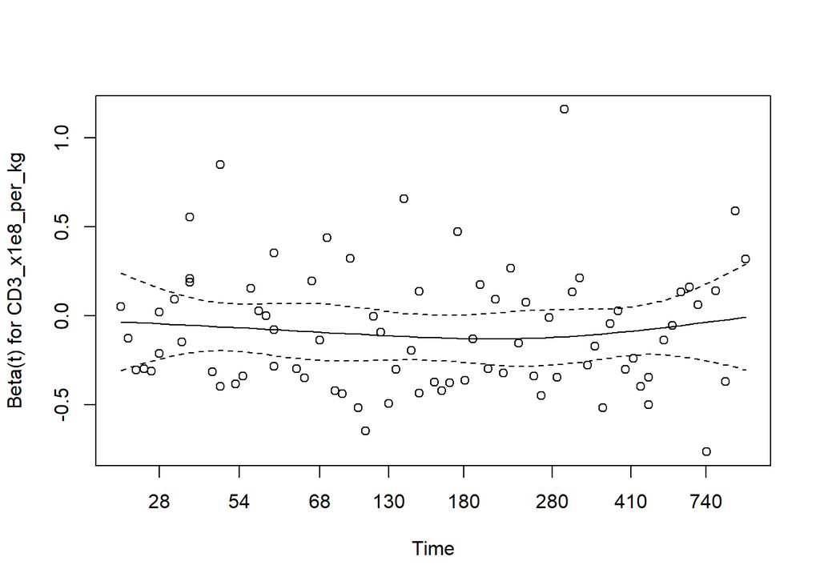

```r
# create plot of schoenfeld resids
wt_sch <- cox.zph(cox_mod)
plot(wt_sch) # maybe see a pattern of decreaseing here over time
```

```r
# check summary to see if problematic
wt_sch
```

```
##                                 chisq df    p
## CD34_x1e6_per_kg...CD34kgx10d6 0.1585  1 0.69
## CD3_x1e8_per_kg                0.0127  1 0.91
## GLOBAL                         0.1777  2 0.91
```

Let’s undergo a new round of model selection to see which variables are seen as most important in our data set to predict survival time.

We can try to use step selection here:

First we take out survival outcome and relapse

```r
bone2 <- bone %>% dplyr::select(-c(survival_status, relapse)) %>% drop_na()
```

```r
library(MASS)
full_model <- lm(survival_time ~ ., data = bone2)

# Stepwise regression model
step_model <- stepAIC(full_model,
                    direction = "both",
                    trace = FALSE)
summary(step_model)
```

```
##
## Call:
## lm(formula = survival_time ~ gender_match + stem_cell_source +
##     CD34_x1e6_per_kg...CD34kgx10d6 + PLT_recovery + extensive_chronic_GvHD +
##     HLA_mismatch, data = bone2)
##
## Residuals:
##      Min       1Q   Median       3Q      Max
## -1612.84  -507.03   -34.31   444.11  1916.33
##
## Coefficients:
##                                    Estimate Std. Error t value Pr(>|t|)
## (Intercept)                      -5.728e+00  2.143e+02  -0.027 0.978707
## gender_matchother                 3.735e+02  1.433e+02   2.607 0.009937 **
## stem_cell_sourceperipheral_blood -4.328e+02  1.437e+02  -3.012 0.002986 **
## CD34_x1e6_per_kg...CD34kgx10d6    1.016e+01  6.088e+00   1.669 0.096887 .
## PLT_recovery                     -3.782e-04  2.208e-04  -1.713 0.088454 .
## extensive_chronic_GvHDno          1.048e+03  1.759e+02   5.957 1.39e-08 ***
## extensive_chronic_GvHDyes         7.932e+02  2.118e+02   3.744 0.000246 ***
## HLA_mismatchmismatched            2.964e+02  1.509e+02   1.964 0.051083 .
## ---
## Signif. codes:  0 '***' 0.001 '**' 0.01 '*' 0.05 '.' 0.1 ' ' 1
##
## Residual standard error: 713.5 on 174 degrees of freedom
## Multiple R-squared:  0.3103, Adjusted R-squared:  0.2826
## F-statistic: 11.18 on 7 and 174 DF,  p-value: 1.169e-11
```

```r
# forward regression model
forward_model <- stepAIC(full_model,
                    direction = "forward",
                    trace = FALSE)
summary(forward_model)
```

```
##
## Call:
## lm(formula = survival_time ~ donor_age + donor_age_below_35 +
##     donor_ABO + donor_CMV + recipient_age + recipient_age_below_10 +
##     recipient_age_int + recipient_gender + recipient_body_mass +
##     recipient_ABO + recipient_rh + recipient_CMV + disease +
##     disease_group + gender_match + ABO_match + CMV_status + HLA_match..out.of.10. +
##     HLA_mismatch + antigen + allele + HLA_group_1 + risk_group +
##     stem_cell_source + tx_post_relapse + CD34_x1e6_per_kg...CD34kgx10d6 +
##     CD3_x1e8_per_kg + CD3_to_CD34_ratio + ANC_recovery + PLT_recovery +
##     acute_GvHD_II_III_IV + acute_GvHD_III_IV + time_to_acute_GvHD_III_IV +
##     extensive_chronic_GvHD, data = bone2)
##
## Residuals:
##      Min       1Q   Median       3Q      Max
## -1436.91  -369.26   -23.82   437.08  1497.75
##
## Coefficients: (8 not defined because of singularities)
##                                    Estimate Std. Error t value Pr(>|t|)
## (Intercept)                      -1.644e+04  1.120e+04  -1.468  0.14465
## donor_age                        -8.819e+00  1.509e+01  -0.585  0.55987
## donor_age_below_35yes            -2.067e+02  2.387e+02  -0.866  0.38815
## donor_ABOA                       -1.014e+02  1.519e+02  -0.668  0.50567
## donor_ABOAB                       8.771e+01  2.619e+02   0.335  0.73825
## donor_ABOB                       -1.894e+02  2.035e+02  -0.930  0.35393
## donor_CMVabsent                  -5.179e+02  8.663e+02  -0.598  0.55108
## donor_CMVpresent                 -4.596e+02  8.737e+02  -0.526  0.59976
## recipient_age                    -1.407e+01  4.464e+01  -0.315  0.75318
## recipient_age_below_10yes         1.204e+03  8.270e+02   1.456  0.14794
## recipient_age_int10_20            1.431e+03  8.533e+02   1.677  0.09595 .
## recipient_age_int5_10             8.861e+01  2.577e+02   0.344  0.73149
## recipient_gendermale              8.975e+00  1.464e+02   0.061  0.95120
## recipient_body_mass               6.648e-01  8.613e+00   0.077  0.93859
## recipient_ABO0                   -1.444e+03  1.243e+03  -1.162  0.24749
## recipient_ABOA                   -1.498e+03  1.233e+03  -1.214  0.22687
## recipient_ABOAB                  -1.321e+03  1.260e+03  -1.048  0.29645
## recipient_ABOB                   -1.337e+03  1.248e+03  -1.071  0.28635
## recipient_rhminus                 1.299e+03  8.921e+02   1.456  0.14775
## recipient_rhplus                  1.110e+03  8.718e+02   1.273  0.20532
## recipient_CMVabsent               4.347e+02  1.092e+03   0.398  0.69124
```

[output cut: 34 more lines]

```
## CD3_x1e8_per_kg                   2.406e+01  2.484e+01   0.968  0.33473
## CD3_to_CD34_ratio                 1.777e+00  7.560e+00   0.235  0.81450
## ANC_recovery                      5.958e-04  5.080e-04   1.173  0.24304
## PLT_recovery                     -3.626e-04  2.957e-04  -1.226  0.22242
## acute_GvHD_II_III_IVyes           2.186e+01  1.604e+02   0.136  0.89183
## acute_GvHD_III_IVyes             -1.590e+01  7.254e+02  -0.022  0.98255
## time_to_acute_GvHD_III_IV         8.494e-05  7.123e-04   0.119  0.90526
## extensive_chronic_GvHDno          1.121e+03  2.303e+02   4.869  3.3e-06 ***
## extensive_chronic_GvHDyes         8.524e+02  2.679e+02   3.182  0.00184 **
## ---
## Signif. codes:  0 '***' 0.001 '**' 0.01 '*' 0.05 '.' 0.1 ' ' 1
##
## Residual standard error: 751.6 on 126 degrees of freedom
## Multiple R-squared:  0.4458, Adjusted R-squared:  0.2039
## F-statistic: 1.843 on 55 and 126 DF,  p-value: 0.002658
```

Next, we can try backwards selection:

This models suggests to use the following predictors:

```r
backward_model <- step(full_model,
                      direction = "backward",
                      trace = FALSE)

summary(backward_model)
```

```
##
## Call:
## lm(formula = survival_time ~ gender_match + stem_cell_source +
##     CD34_x1e6_per_kg...CD34kgx10d6 + PLT_recovery + extensive_chronic_GvHD,
##     data = bone2)
##
## Residuals:
##      Min       1Q   Median       3Q      Max
## -1416.47  -503.91   -61.43   457.65  1905.94
##
## Coefficients:
##                                    Estimate Std. Error t value Pr(>|t|)
## (Intercept)                       3.875e+01  2.148e+02   0.180 0.857079
## gender_matchother                 3.643e+02  1.444e+02   2.523 0.012512 *
## stem_cell_sourceperipheral_blood -4.105e+02  1.444e+02  -2.842 0.005010 **
## CD34_x1e6_per_kg...CD34kgx10d6    1.115e+01  6.116e+00   1.822 0.070124 .
## PLT_recovery                     -3.898e-04  2.225e-04  -1.752 0.081525 .
## extensive_chronic_GvHDno          1.020e+03  1.768e+02   5.769 3.54e-08 ***
## extensive_chronic_GvHDyes         7.836e+02  2.135e+02   3.670 0.000322 ***
## ---
## Signif. codes:  0 '***' 0.001 '**' 0.01 '*' 0.05 '.' 0.1 ' ' 1
##
## Residual standard error: 719.3 on 175 degrees of freedom
## Multiple R-squared:  0.295,  Adjusted R-squared:  0.2709
## F-statistic: 12.21 on 6 and 175 DF,  p-value: 1.887e-11
```

```r
#cox_obj <- Surv(bone$survival_time, bone$survival_status)
#cox_model <- coxph(cox_obj ~ as.factor(recipient_rh), as.factor(gender_match), as.factor(antigen), as.factor(allele), as.factor(stem_cell_source), CD34_x1e6_per_kg...CD34kgx10d6, PLT_recovery, as.factor(extensive_chronic_GvHD), data = bone, ties = "exact")

# provide score and LR test statistic
#summary(cox_model)
```

In one of our secondary questions, we ask if one of sources of bone marrow (either from peripheral stem cell or bone marrow stem cell) has a greater chance of survival than the other. We can use a survival analysis model to calculate the hazard rate with stem cell source being our variable.

The estimated hazard ratio for mortality for the stem cell source of peripheral blood compared to bone marrow is 0.6259, on average, (95% CI: 0.3899, 1.005) holding all other covariates constant, which indicates a 37.4% decrease in mortality. This finding indicates a positive effect against mortality when using peripheral blodd as a stem cell source rather than bone marrow. This fact also supports our exploratory graph below.

```r
cox_mod_source <- coxph(cox_obj ~ as.factor(stem_cell_source), data = bone, ties = "exact")

# provide score and LR test statistic
summary(cox_mod_source)
```

```
## Call:
## coxph(formula = cox_obj ~ as.factor(stem_cell_source), data = bone,
##     ties = "exact")
##
##   n= 187, number of events= 85
##
##                                                coef exp(coef) se(coef)      z
## as.factor(stem_cell_source)peripheral_blood -0.4686    0.6259   0.2415 -1.941
##                                             Pr(>|z|)
## as.factor(stem_cell_source)peripheral_blood   0.0523 .
## ---
## Signif. codes:  0 '***' 0.001 '**' 0.01 '*' 0.05 '.' 0.1 ' ' 1
##
##                                             exp(coef) exp(-coef) lower .95
## as.factor(stem_cell_source)peripheral_blood    0.6259      1.598    0.3899
##                                             upper .95
## as.factor(stem_cell_source)peripheral_blood     1.005
##
## Concordance= 0.549  (se = 0.025 )
## Likelihood ratio test= 3.5  on 1 df,   p=0.06
## Wald test            = 3.77  on 1 df,   p=0.05
## Score (logrank) test = 3.83  on 1 df,   p=0.05
```

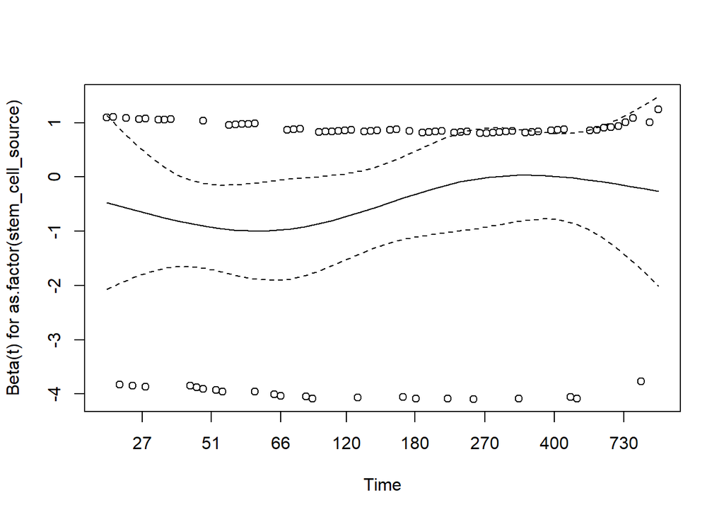

```r
# create plot of schoenfeld resids
wt_sch_source <- cox.zph(cox_mod_source)
plot(wt_sch_source) # slight decrease then increase over time
```

```r
# check summary to see if problematic
wt_sch_source
```

```
##                             chisq df    p
## as.factor(stem_cell_source)   1.5  1 0.22
## GLOBAL                        1.5  1 0.22
```

```r
library(dplyr)
library(pander)
#stem_cell_source
#2x2 table with margins
tab20 <- table(bone$survival_status,bone$stem_cell_source)
tab20 <- prop.table(tab20,2)
addmargins(tab20)  %>% pander(caption = "Stem Cell Source")
```

Stem Cell Source

|  | bone_marrow | peripheral_blood | Sum |
| --- | --- | --- | --- |
| **0** | 0.4286 | 0.5793 | 1.008 |
| **1** | 0.5714 | 0.4207 | 0.9921 |
| **Sum** | 1 | 1 | 2 |

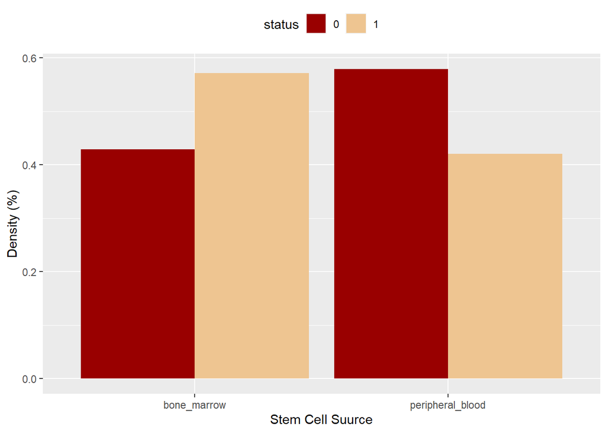

```r
tab20 <- tab20 %>% data.frame()

p20 <- ggplot(aes(Var2, Freq, fill = Var1), data = tab20) +
  geom_col(position = "dodge") +
  xlab("Stem Cell Suurce") +
  ylab ("Density (%)") +
  labs(fill='status') +
  scale_fill_manual(values=c("#990000", "burlywood2"))+
  theme(legend.position="top")

p20
```